# Evaluación curso R

Paloma Rami López

## Entrega

- Recuerda completar tu **nombre en el apartado author**.
- Además del código, no olvides completar las respuestas a las preguntas indicadas en negrita.
- Si tienes dudas/dificultades, **puedes contactar con los profesores**.
- Deadline: **24-06-2026**
- Puedes realizar la entrega en el mail: **constantino.garciama@ceu.es**.
- La entrega consistirá en el fichero que se genera al hacer `Knit` (un fichero `html` o `pdf`).

## Apuestas de adolescentes en UK

El conjunto de datos `teengamb.csv` contiene datos sobre las tasas de juego entre los adolescentes en Gran Bretaña, su género y estatus socioeconómico. Una pregunta que nos puede interesar es **si los ingresos del adolescente y su sexo influyen en la cantidad de dinero apostado (céntrate solo en las variables `income`, `sex` y `gamble`)** … Sigue los siguientes pasos para crear un ANCOVA…

### 1a) Carga los datos…

```r
# Carga los datos

juego_adolescentes = read.csv(file = "teengamb.csv")
head(juego_adolescentes)
```

```
##      sex status income verbal     gamble
## 1 Female     51   2.00      8  20.965805
## 2 Female     28   2.50      8 -11.091514
## 3 Female     37   2.00      6  -8.586763
## 4 Female     28   7.00      4  17.351732
## 5 Female     65   2.00      8 -17.252409
## 6 Female     61   3.47      6  14.878533
```

### 1b) Visualiza los datos…

…para valorar si el modelo debe incluir interacciones. Para ello, escribe el código que genera una gráfica similar a la siguiente:

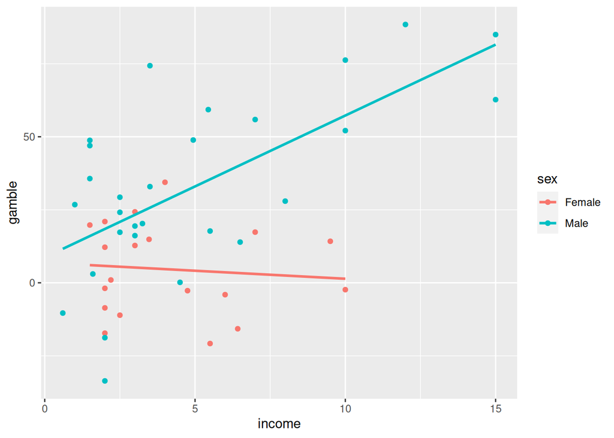

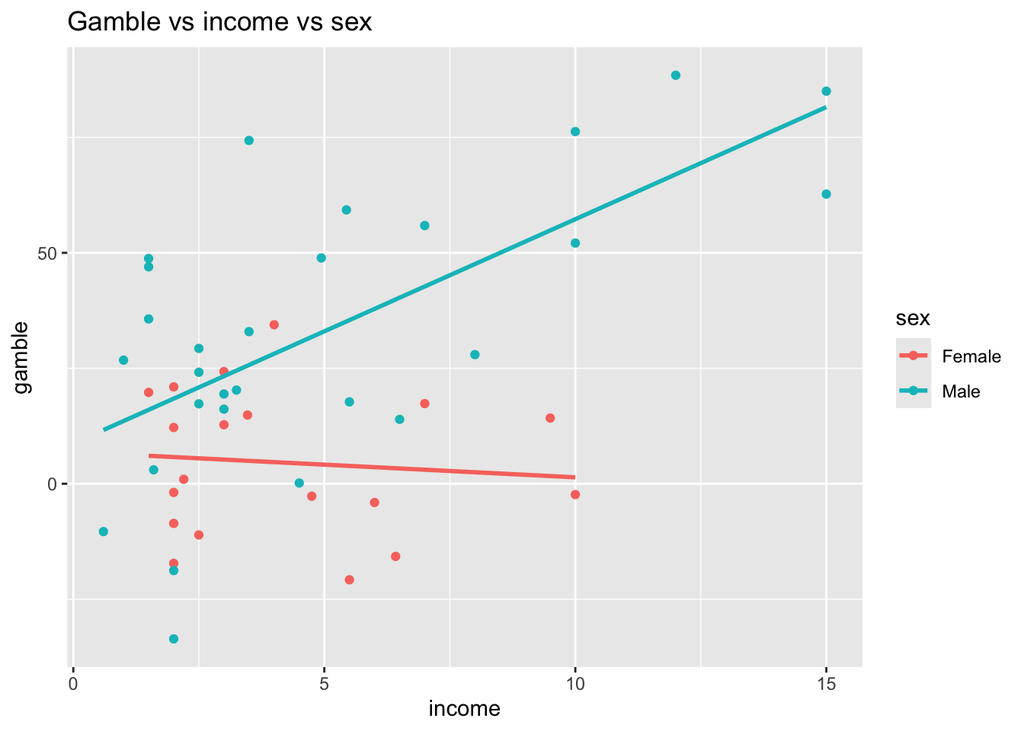

```r
library("tidyverse")  # carga ggplot
ggplot(juego_adolescentes, aes(x = income, col = sex, y = gamble)) +
  geom_point() +
  geom_smooth(method="lm", se = FALSE) +
labs(title = "Gamble vs income vs sex",
     x = "income", y = "gamble")
```

```r
# completa el siguiente código
# ggplot(teengamb, aes(x = ????, col = ????, y=????)) +
#geom_???????? + # añade la geometría adecuada para los puntos
#geom_?????????  # añade las rectas de regresión
```

La gráfica anterior apoya que hay interacciones entre las variables `sex` e `income`. **Explica los motivos brevemente** (Pista: ¿son las rectas paralelas?)

Las rectas no son paralelas, por lo que si que existe interacción entre las variables sex e income. En este caso, significa que los hombres cuanto más dinero ganan, más apuestan realizan; mientras que en el caso de las mujeres, la cantidad de apuestas no está influenciada por el dinero.

### 2) Crea el modelo…

… y obtén los intervalos de confianza para los coeficientes y su significación.

```r
# Crea un modelo con interacciones en base a tu conclusión del apartado anterior
# gamb_model <- lm(gamble ~ income * sex, ??????)

juego_modelo= lm(gamble ~ income * sex, data = juego_adolescentes)

# Obtén p-valores e intervalos de confianza. Usa summary y confint

summary(juego_modelo)
```

```
##
## Call:
## lm(formula = gamble ~ income * sex, data = juego_adolescentes)
##
## Residuals:
##     Min      1Q  Median      3Q     Max
## -52.025 -15.479  -3.559  14.022  48.625
##
## Coefficients:
##                Estimate Std. Error t value Pr(>|t|)
## (Intercept)      6.8743     9.2446   0.744   0.4612
## income          -0.5489     1.9024  -0.289   0.7743
## sexMale          1.8427    11.1946   0.165   0.8700
## income:sexMale   5.4050     2.1435   2.522   0.0155 *
## ---
## Signif. codes:  0 '***' 0.001 '**' 0.01 '*' 0.05 '.' 0.1 ' ' 1
##
## Residual standard error: 20.97 on 43 degrees of freedom
## Multiple R-squared:  0.5105, Adjusted R-squared:  0.4764
## F-statistic: 14.95 on 3 and 43 DF,  p-value: 8.279e-07
```

```r
confint(juego_modelo)
```

```
##                     2.5 %    97.5 %
## (Intercept)    -11.769152 25.517839
## income          -4.385455  3.287728
## sexMale        -20.733425 24.418773
## income:sexMale   1.082260  9.727751
```

### 3) Valora si las asunciones del modelo se cumplen

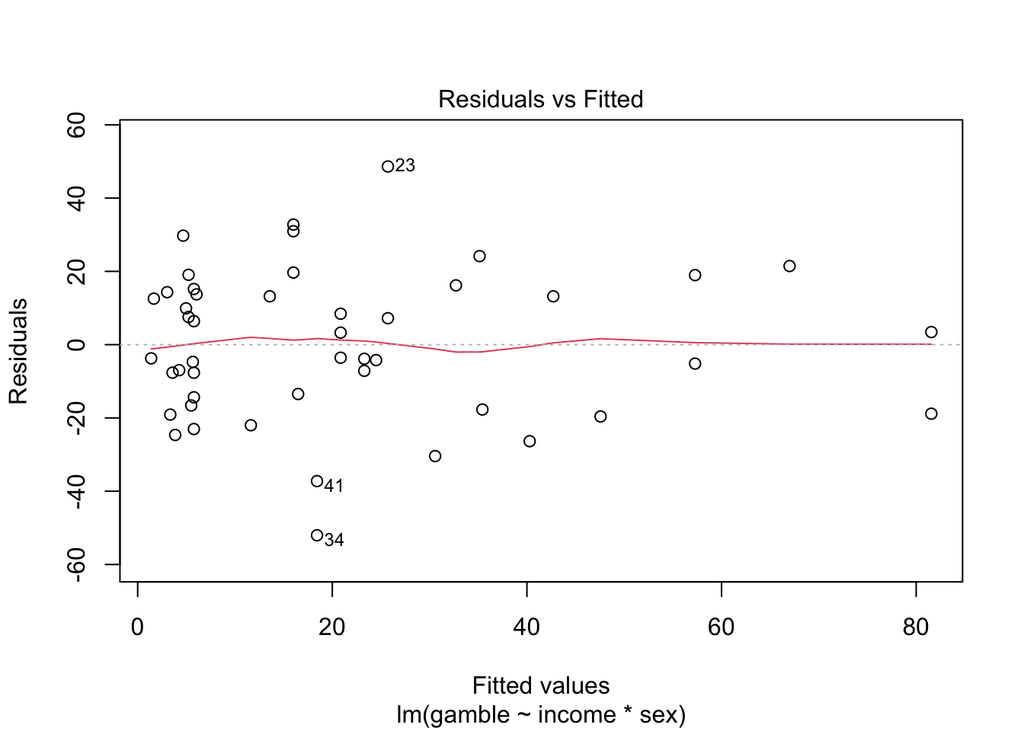

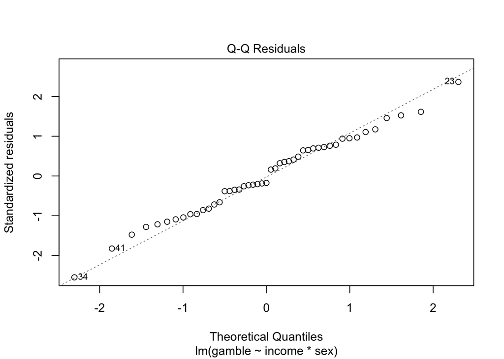

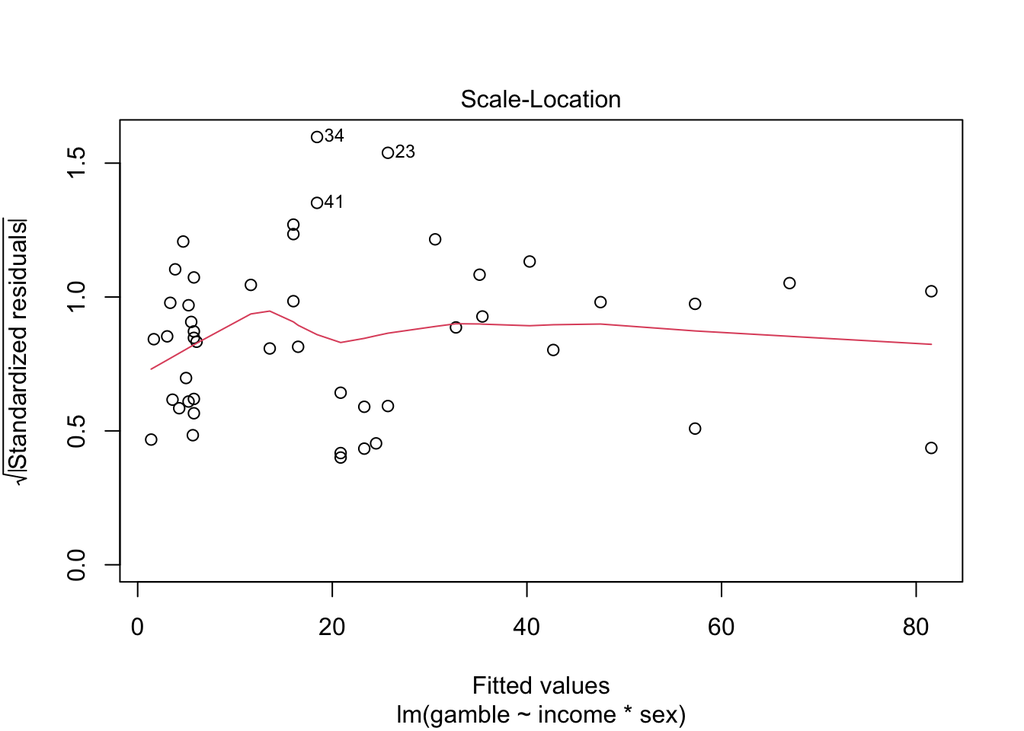

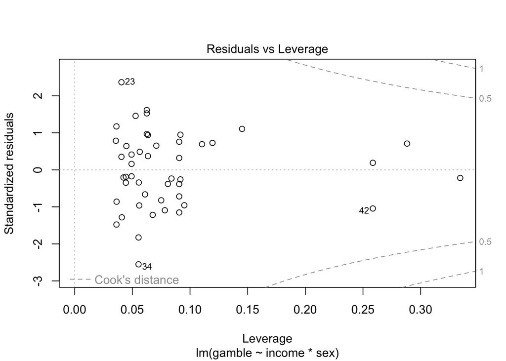

```r
# Interpretar las 4 gráficas siguientes para decidir si las asunciones del modelo
# se cumplen
# plot(gamb_model, ask = FALSE)

plot(juego_modelo, ask = FALSE)
```

**¿Es el modelo correcto?:**

El modelo es correcto ya que en el primer gráfico (Residuals vs. Fitted), los residuos se distribuyen de forma aleatoria cerca del 0, cumpliendo la linealidad. Además, en el segundo gráfico (Q-Q Residuals), los residuos se distribuyen por la línea recta, lo que indica una distribución normal.

### 4) Interpreta los coeficientes y escribe tus conclusiones.

De la tabla de p-valores, podemos concluir que para las mujeres:
$$gambling = 6.87 - 0.5489 * income$$
Mientras que para hombres:
$$gambling
= 8.72 + 4.8561 * income.$$
Fíjate que el coeficiente -0.5489 no es significativo, mientras que el salto en las pendientes entre mujeres y hombres es de 5.4050 y sí es significativo.

**¿Cuáles de las siguientes conclusiones son correctas? (puede haber varias)**

1. Los hombres y mujeres adolescentes apuestan de la misma forma. Esta oración es falsa ya que las pendientes de ambos grupos son diferentes entre sí, y de forma significativa.
2. **No evidencia suficiente de que las mujeres apuesten de forma diferente según sus ingresos.** Es verdadera ya que la pendiente de las mujeres no es significativa.
3. **Para los hombres: a mayor nivel de ingresos, mayor cantidad apostada.** Es verdadera.
4. La diferencia entre las pendientes de hombres y mujeres no es significativa. Es falsa ya que la diferencia entre ambas pendientes sí que es significativa.